# Day4–Quantiles and Boxplots

## Today’s Agenda

- Quantiles
- Logical Operators

## Quantiles

```r
library(palmerpenguins)
```

```r
mean(penguins$flipper_length_mm, na.rm=TRUE)
```

```
## [1] 200.9152
```

```r
# The mean flipper length is 200.9 mm
```

The mean tells me some information about where the center of our data is distributed

- a **quantile** tells you the data point for which $x \%$ of your data is less than that value.

```r
# find the flipper length for which 20% of penguins have a flipper length less than that value
quantile(penguins$flipper_length_mm,.20,na.rm = TRUE)
```

```
## 20%
## 188
```

```r
# also known as the 20th percentile = 188mm
```

## Data Tidying

- We don’t want to type `na.rm = TRUE` over and over, so, let’s remove the missing data all at once.

```r
clean_flipper_length <- na.omit(penguins$flipper_length_mm)

clean_penguins <- na.omit(penguins)

quantile(clean_flipper_length, 0.2)
```

```
## 20%
## 188
```

```r
# wanting the 25th, 50th, and 75th percentile is so common that R has a built in way to do that:
quantile(clean_flipper_length)
```

```
##   0%  25%  50%  75% 100%
##  172  190  197  213  231
```

## Graphing numeric data

- what is the best visual representation for quantiles?

```r
library(tidyverse)
```

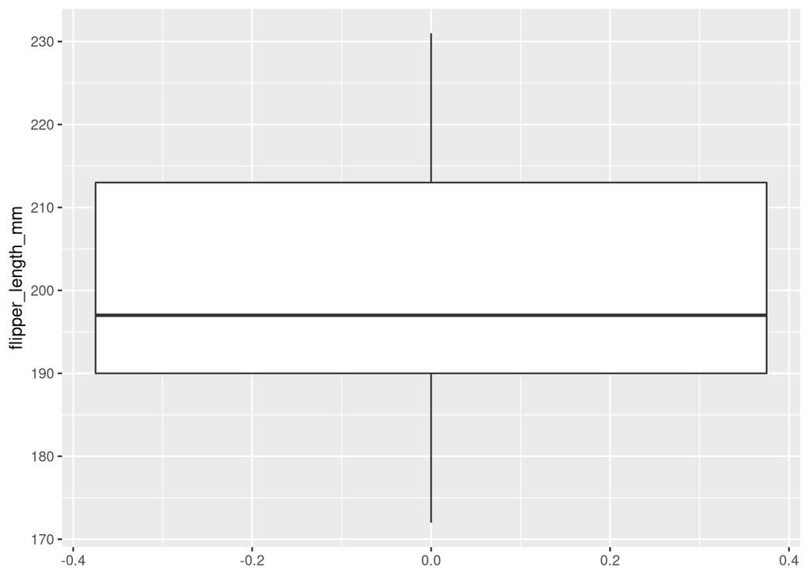

```r
# boxplot for flipper length
ggplot(penguins, aes( y= flipper_length_mm)) + geom_boxplot()
```

- The bottom of the box in a boxplot is the 25th percentile
- line is the 50th percentile
- the top is the 75th
- the lines coming out of the box are whiskers

## filter data

```r
# to get a subset of your data use the filter() function
biscoe_penguins <- filter(penguins, island == "Biscoe")

# all penguins from biscoe whose flipper length is greater than 213
big_flipper_biscoe <- filter(penguins, island == "Biscoe" & flipper_length_mm > 213)

big_flipper_or_biscoe <- filter(penguins, island == "Biscoe" | flipper_length_mm > 213)

other_islands <- filter(penguins, island != "Biscoe")
```

### Activities

1. Find the a value of body mass for which $30 \%$ of penguins are below that mass.
2. Find the a value of body mass for which $60 \%$ of penguins are above that mass.
3. Make a box plot for flipper length.
4. Make a boxplot for body mass where each island is separated into it’s own boxplot.
5. How many penguins are in the study are not from Torgesen?
6. How many penguins in the study have a flipper length less than $190$ and a body mass greater than $4700$?